# Naming Metrics - utMetrics

## Metric Names

Metric names are designed to give a clear understanding of the metric. Metric names are derived from components of the Metric.

- Season (if applicable)
- Computation
- by
- Partition(s) (if more than one partition they will be hyphenated)
- :: Segment(s) (if more than one segment they will be hyphenated)

### Example 1: Fall Census Headcount by Student Type::Transfer

- Fall is the Season
- Census Headcount is the Computation
- by
- Student Type is the Partition
- :: notes there is a segment
- Transfer is the Segment

The Metric will show the Fall Census Headcount for Transfer (student type) students for the last 5 years.

### Example 2: Fall to Fall Comeback Rate by College-Minority::CHASS-Minority

- Season - not applicable
- Fall to Fall Comeback Rate is the Computation
- by
- College-Minority - College, Minority are the Partitions (hyphenated)
- :: notes there is a segment
- CHASS-Minority - CHASS is the college Segment and minority is the Minority Segment (the two segments are hyphenated, i.e., CHASS-Minority).

The Metric will show the Fall to Fall Comeback Rate for CHASS (college) Minority (minority) students.

### Metric Name Diagram

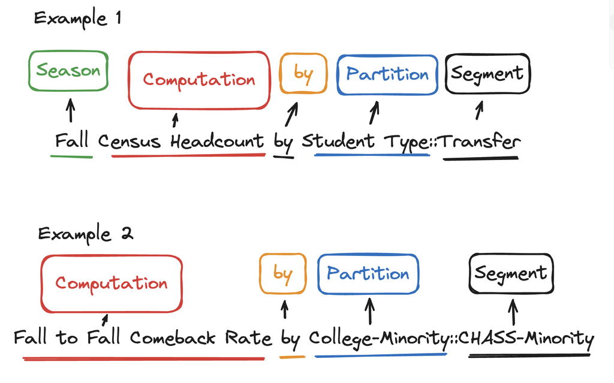

Metric Names Diagram

### List of Computations

List of Computations

|  | Computation |
| --- | --- |
| 1 | 150 Percent Graduation Rate |
| 2 | Census FTE |
| 3 | Census Headcount |
| 4 | Census Section Count |
| 5 | End Of Term FTE |
| 6 | End Of Term Headcount |
| 7 | End Of Term Section Count |
| 8 | Fall To Fall Cohort Retention |
| 9 | Fall To Fall Come Back Rate |
| 10 | Fall To Fall Return Rate |

[output cut: 6 more lines]

### List of Computations and Partitions

List of Computations and Partitions

|  | Computation | Partition |
| --- | --- | --- |
| 1 | 150 Percent Graduation Rate | All Cohort Students |
| 2 | 150 Percent Graduation Rate | Cohort-Entering College |
| 3 | 150 Percent Graduation Rate | Cohort-Gender |
| 4 | 150 Percent Graduation Rate | Cohort-Race Ethnicity |
| 5 | 150 Percent Graduation Rate | Cohort-Race Ethnicity-Gender |
| 6 | 150 Percent Graduation Rate | Entering College |
| 7 | 150 Percent Graduation Rate | Ipeds Cohort |
| 8 | Census FTE | Budget Code |
| 9 | Census FTE | College |
| 10 | Census FTE | College-Course Level |

[output cut: 187 more lines]

### List of Metrics

List of Computations, Partitions, and Segments

|  | metric | Computation | Partition | Segment |
| --- | --- | --- | --- | --- |
| 1 | 150 Percent Graduation Rate By All Cohort Students:all cohort students | 150 Percent Graduation Rate | All Cohort Students | all cohort students |
| 2 | 150 Percent Graduation Rate By Cohort-Entering College:First Time Freshman-CHASS | 150 Percent Graduation Rate | Cohort-Entering College | First Time Freshman-CHASS |
| 3 | 150 Percent Graduation Rate By Cohort-Entering College:First Time Freshman-COA | 150 Percent Graduation Rate | Cohort-Entering College | First Time Freshman-COA |
| 4 | 150 Percent Graduation Rate By Cohort-Entering College:First Time Freshman-COB | 150 Percent Graduation Rate | Cohort-Entering College | First Time Freshman-COB |
| 5 | 150 Percent Graduation Rate By Cohort-Entering College:First Time Freshman-COE | 150 Percent Graduation Rate | Cohort-Entering College | First Time Freshman-COE |
| 6 | 150 Percent Graduation Rate By Cohort-Entering College:First Time Freshman-COHS | 150 Percent Graduation Rate | Cohort-Entering College | First Time Freshman-COHS |
| 7 | 150 Percent Graduation Rate By Cohort-Entering College:First Time Freshman-CSET | 150 Percent Graduation Rate | Cohort-Entering College | First Time Freshman-CSET |
| 8 | 150 Percent Graduation Rate By Cohort-Entering College:First Time Freshman-GCO | 150 Percent Graduation Rate | Cohort-Entering College | First Time Freshman-GCO |
| 9 | 150 Percent Graduation Rate By Cohort-Entering College:First Time Freshman-NA Entering College | 150 Percent Graduation Rate | Cohort-Entering College | First Time Freshman-NA Entering College |
| 10 | 150 Percent Graduation Rate By Cohort-Entering College:First Time Freshman-UCOL | 150 Percent Graduation Rate | Cohort-Entering College | First Time Freshman-UCOL |

[output cut: 3786 more lines]